# Lecture 03: From Sample to Population

How Certain Is an Estimate?

Anchor question: We observe wages for only 50 workers. How much should we trust their average wage as an estimate of the average wage in the population?

The lecture moves from **variation in individual outcomes** to **variation in estimates**, then to sampling distributions, standard errors, the central limit theorem, and confidence intervals.

## Learning outcomes

After this lecture, students should be able to:

1. **Distinguish** a population parameter, an estimator, and an estimate, and explain why estimates change across random samples.
2. **Predict and diagnose** how sample size and population variability affect the precision and sampling distribution of an estimator.
3. **Construct and interpret** a confidence interval and justify what a 95% confidence level does—and does not—mean.

**Note**

Pre-class / reference reading

Read **Appendix C.1–C.5**. Concentrate on population versus sample, estimate versus estimator, sampling variation, the sampling distribution of the sample mean, standard errors, the central limit theorem, and interval estimation. The algebraic proofs are supporting material rather than the center of the live lecture.

**Tip**

You do not need to memorise this

Do **not** memorise critical values, statistical tables, the detailed derivation of unbiasedness, the proof of $\operatorname{Var}(\bar Y)=\sigma^2/N$, the $N-1$ derivation for sample variance, or formulas for higher central moments. R can supply the mechanics. You should be able to explain what the resulting quantities mean and when the inference is credible.

## 0. Retrieval and connection

Last lecture distinguished an individual wage from a conditional mean such as

$$E(WAGE\mid EDUC=16).$$

**Retrieval question:** Two workers have the same education, but one earns NOK 260/hour and another NOK 390/hour. Does this contradict the claim that they have the same conditional expected wage?

**TipClick to view Answer**

No. A conditional expectation describes the center of a distribution, not an exact individual outcome.

Now change the unit of randomness.

> Suppose we take two different random samples of 50 workers with the same education. Must their **average wages** be identical?

No.

$$\boxed{W_i-E(W)\quad\neq\quad \bar W-\mu}$$

The first is **individual variation**. The second is **sampling variation**.

**Connection:** Last lecture randomness meant that individuals differed. Today randomness means that **our estimate itself would have been different if we had observed another sample**.

## 1. The Hook

A firm is preparing a labour-cost budget. It wants the population mean hourly wage for a particular type of skilled worker:

$$\mu=E(WAGE).$$

The firm cannot observe every worker. It randomly samples

$$N=50$$

workers.

**Initial decision:** Suppose the sample mean is about NOK 325/hour. Should the firm use that number as if it were the population mean?

1. Yes—it is our best available estimate, so uncertainty no longer matters.
2. No—50 observations are automatically too few.
3. Yes as a **point estimate**, but we must quantify its uncertainty.
4. We cannot learn anything about a population from a sample.

Now ask the question that drives the lecture:

> If we throw away these 50 observations and sample another 50 workers, **how different could the new estimate reasonably be?**

## 2. Minimal theory

### Parameter, estimator, estimate — Appendix C.2–C.3

Population parameter:

$$\mu=E(WAGE).$$

Estimator:

$$\bar W=\frac{1}{N}\sum_{i=1}^N W_i.$$

One realized estimate in today’s synthetic sample is

$$\bar w=325.42.$$

**Important**

Key distinction

**The number on your screen is an estimate. The procedure that generated it is the estimator.**

Before the sample is observed, $\bar W$ is a random variable. Different random samples generate different values of $\bar w$.

### Sampling distribution — Appendix C.3

Imagine repeating the study many times:

$$\bar W_1,\bar W_2,\bar W_3,\ldots$$

Their distribution is the **sampling distribution** of the estimator.

For an iid random sample,

$$E(\bar W)=\mu,$$

and

$$\operatorname{Var}(\bar W)=\frac{\sigma^2}{N}.$$

The second expression says that more data reduce sampling uncertainty.

### Standard deviation versus standard error — Appendix C.4.1

Population/sample standard deviation describes variation **between workers**:

$$\sigma\quad\text{or}\quad s.$$

The standard error describes variation **between estimates**:

$$se(\bar W)=\frac{s}{\sqrt N}.$$

$$\boxed{SD:\ \text{How different are workers?}}
\qquad
\boxed{SE:\ \text{How different would estimates be?}}$$

### Central Limit Theorem and confidence intervals — Appendix C.3.4 and C.5

Even when individual wages are not normally distributed, the sampling distribution of the mean becomes increasingly close to normal as the sample grows under the conditions of the CLT.

With unknown population variance, inference about the mean is based on

$$\frac{\bar W-\mu}{s/\sqrt N},$$

leading to the familiar interval

$$\bar W\pm t_c\,se(\bar W).$$

The formula is easy. **The interpretation is the difficult part.**

### Explore the square-root rule

**Population SD for the teaching example:** NOK 105/hour

**Sample size $N$:** 50

Theoretical standard error: 14.85 NOK/hour

Try $N=50$, $N=100$, and $N=200$. What has to happen to $N$ to halve the standard error?

**Important**

Prediction worth remembering

Because

$$se(\bar W)\propto\frac{1}{\sqrt N},$$

we need roughly **four times as many observations** to cut the standard error in half.

## 3. The Econometric Lab

The wage population below is **synthetic**. We deliberately know its true mean, NOK 315/hour, so that we can inspect whether our inferential procedures work. The population is mildly right-skewed, with population SD NOK 105/hour.

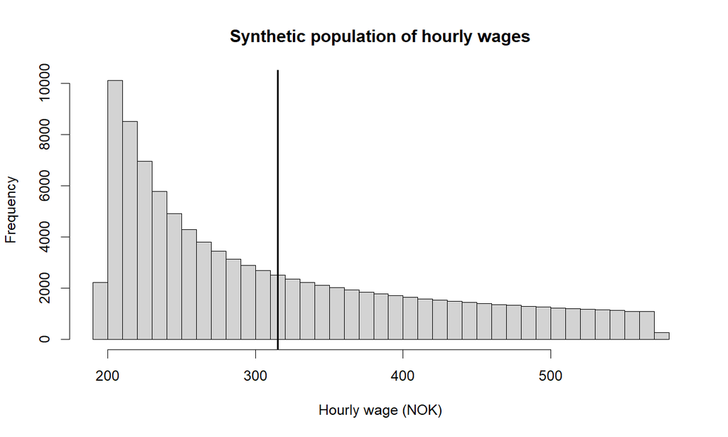

The population is right-skewed even though the sampling distribution of the mean will become much more regular.

### Lab Step 1 — One sample gives one answer

**Question:** What would we conclude if this were the only sample we ever observed?

**Predict before running:** The sample mean should be near the population mean, but should it equal it exactly?

**R action:**

```r
anchor_seed <- 4820
wage <- draw_wages(50, anchor_seed)

mean(wage)
sd(wage)
sd(wage) / sqrt(length(wage))
```

**Result:**

$$\bar w=325.42,\qquad s=102.98,\qquad se(\bar W)=14.56.$$

**Interpretation:** NOK 325.42 is an **estimate**, not a known population fact.

**Decision:** The firm can use NOK 325.42 as its point estimate, but it still needs a measure of sampling uncertainty.

### Lab Step 2 — What if we repeated the study?

**Question:** What would happen if we sampled another 50 workers, then another 50, thousands of times?

**Predict before running:** Will the new estimates be identical, systematically above 315, systematically below 315, or simply different but centered near 315?

**R action:**

```r
samples_50 <- simulate_samples(n = 50, B = 5000, seed = 31050)
means_50 <- rowMeans(samples_50)

mean(means_50)
sd(means_50)
hist(means_50)
```

**Result:** The 5,000 simulated estimates average NOK 314.86, and their empirical standard deviation is NOK 14.81.

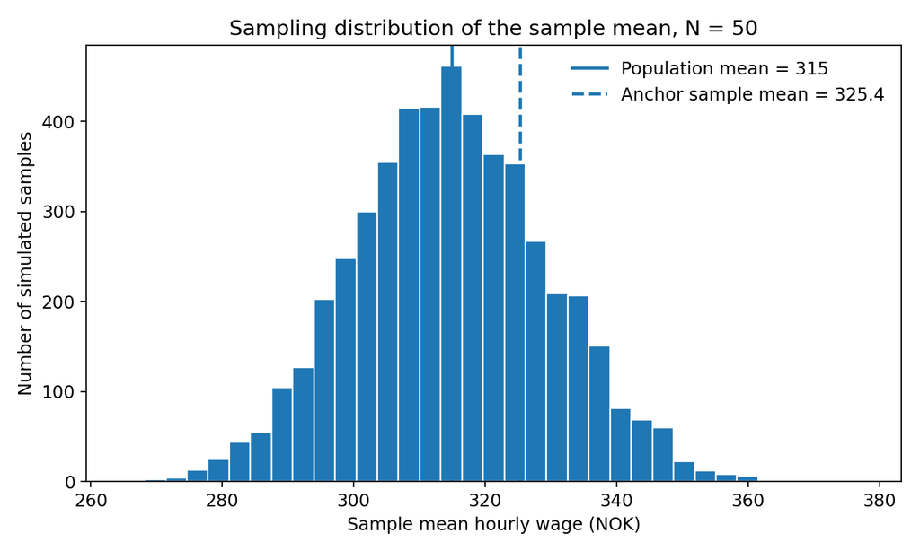

One realized sample mean is only one draw from the sampling distribution of the estimator.

**Interpretation:** This is a distribution of **sample means**, not a distribution of individual wages.

**Decision:** Our original NOK 325.42 is one possible realization of $\bar W$. Reporting the estimate alone hides this sampling variation.

### Lab Step 3 — What does sample size buy us?

**Question:** What changes when we use $N=10$, $N=50$, or $N=200$?

Before running the simulation, predict what happens to:

- the **center** of the sampling distribution;
- its **spread**;
- its **shape**.

**R action:**

```r
samples_10  <- simulate_samples(10,  5000, 31010)
samples_50  <- simulate_samples(50,  5000, 31050)
samples_200 <- simulate_samples(200, 5000, 31200)

sd(rowMeans(samples_10))
sd(rowMeans(samples_50))
sd(rowMeans(samples_200))
```

| Sample size | Theoretical $\sigma/\sqrt N$ | Simulated SD of $\bar W$ |
| --- | --- | --- |
| 10 | 33.20 | 33.29 |
| 50 | 14.85 | 14.81 |
| 200 | 7.42 | 7.53 |

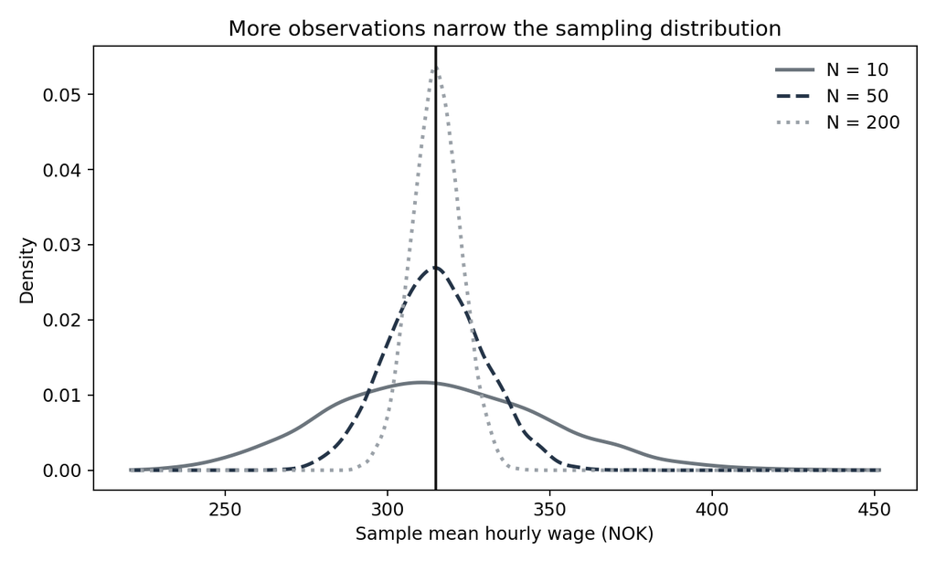

The sampling distribution becomes narrower as N increases, while remaining centered near the same population mean.

**Interpretation:** The center remains approximately at $\mu=315$, while precision improves. Going from $N=50$ to $N=200$ quadruples the data and approximately halves the standard error.

**Decision:** More observations buy precision, but at a square-root rate. Doubling the sample does not double precision.

### Lab Step 4 — The CLT: do not look at the wrong distribution

**Question:** Which distribution needs to become approximately normal for inference about the population mean?

Look again at the right-skewed wage population. Must the **individual wage histogram** itself be normal before we can infer the mean?

**R action:** Compare the histogram of individual wages with the histogram of the 5,000 sample means for $N=50$.

```r
par(mfrow = c(1, 2))
hist(wage_population, breaks = 45, main = "Individual wages")
hist(means_50, breaks = 35, main = "Sample means, N = 50")
par(mfrow = c(1, 1))
```

**Result:** Individual wages remain right-skewed, while the sampling distribution of $\bar W$ is much more symmetric and bell-shaped.

**Interpretation:** The CLT concerns the **sampling distribution of the estimator**. The original data do not have to look normal for the sample mean to become approximately normal in sufficiently large samples.

**Decision:** A skewed wage histogram does not automatically invalidate inference about its mean. Sample size, dependence, representativeness, and the severity of non-normality still matter.

### Lab Step 5 — Deliberate failure: SD is not SE

**Question:** Which measure of variation belongs in an interval for the **population mean**?

Suppose an analyst writes:

```r
mean(wage) + c(-1, 1) * 1.96 * sd(wage)
```

and calls the result a 95% confidence interval for $\mu$.

**Predict before correcting:** Does an interval of roughly NOK 124 to NOK 527 look like uncertainty about the **average wage**, or like dispersion among individual workers?

**Misleading result:**

$$[123.59,\;527.26].$$

**Warning**

The failure

The analyst used the **standard deviation** $s$ rather than the **standard error** $s/\sqrt N$. This is not just a syntax problem. It confuses two different sources of variation.

Correct calculation:

```r
t_critical <- qt(0.975, df = 49)
se_mean <- sd(wage) / sqrt(50)

mean(wage) + c(-1, 1) * t_critical * se_mean
```

which gives

$$[296.16,\;354.69].$$

$$\boxed{s:\ \text{variation among workers}}
\qquad
\boxed{se(\bar W):\ \text{uncertainty about the estimated mean}}$$

**Decision:** The firm can face substantial variation in individual wages and still estimate the **average** wage reasonably precisely.

### Lab Step 6 — What does 95% actually mean?

**Question:** If we repeatedly construct nominal 95% confidence intervals, should all of them contain the true population mean?

Predict the result for 100 repeated samples:

- all 100 contain $\mu$;
- exactly 95 must contain $\mu$;
- approximately 95 should contain $\mu$ over repeated use of the procedure.

**R action:**

```r
ci_samples <- simulate_samples(n = 50, B = 100, seed = 35010)
ci_means <- rowMeans(ci_samples)
ci_sds <- apply(ci_samples, 1, sd)
ci_ses <- ci_sds / sqrt(50)

ci_lo <- ci_means - t_critical * ci_ses
ci_hi <- ci_means + t_critical * ci_ses
ci_cover <- ci_lo <= population_mean & population_mean <= ci_hi

sum(ci_cover)
```

**Result in this reproducible run:** 95 of the 100 intervals contain the true population mean.

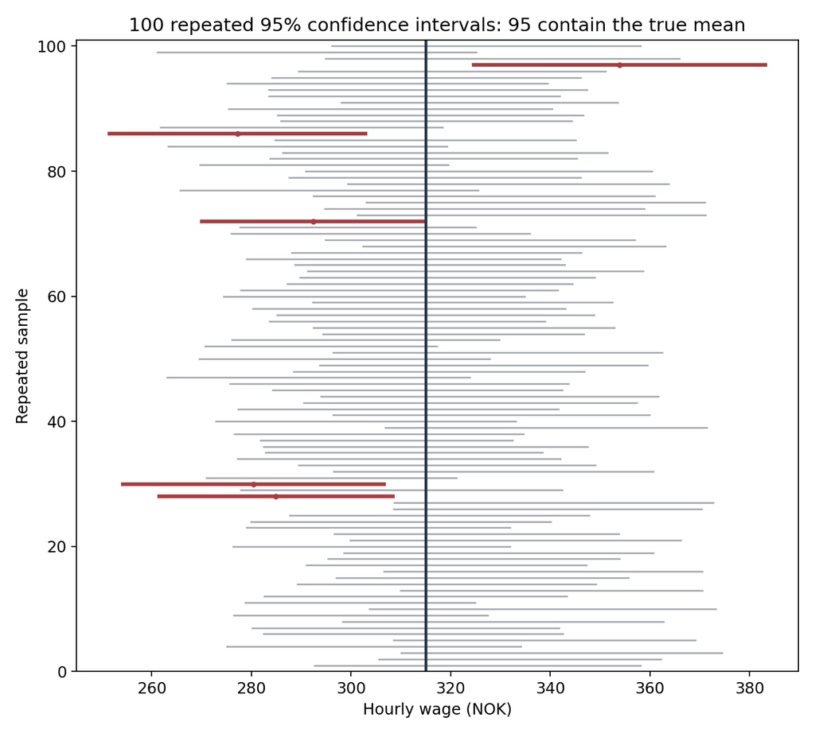

The vertical line is the fixed population mean. Most repeated confidence intervals contain it; some do not.

**Important**

What 95% confidence means here

A realized interval either contains the fixed parameter $\mu$ or it does not. The 95% statement concerns the **long-run performance of the interval procedure under repeated sampling**, not the percentage of individual workers inside the interval.

**Answer to the anchor:** Use the sample mean as the point estimate, but communicate how much it could have changed under another random sample by reporting its standard error and confidence interval.

## 4. The AI Audit

### Prompt to give an LLM

> A company wants to estimate the population mean hourly wage for skilled workers. It obtains an independent random sample of 50 workers. The sample mean wage is NOK 326 per hour and the sample standard deviation is NOK 103.

> Calculate an appropriate 95% confidence interval for the population mean wage. Explain what the interval means, distinguish the standard deviation from the standard error, and explain how the precision would change if the sample size increased from 50 to 200 while the wage variability remained approximately unchanged.

### Audit framework

Do not grade the LLM by asking only whether it produced the right number. Audit the answer.

1. **What is being estimated?** Does it distinguish $\mu$, $\bar W$, and $\bar w$?
2. **Which uncertainty measure is used?** Does it use $se(\bar W)=s/\sqrt N$ rather than $s$?
3. **Is the confidence interval interpreted correctly?** It is not an interval containing 95% of workers.
4. **Is the square-root rule understood?** Moving from $N=50$ to $N=200$ should approximately halve the SE.
5. **Are assumptions mentioned?** Random sampling, independence, population relevance, and distributional/large-sample justification matter.

For reference, the numerical answer is approximately

$$se(\bar W)=\frac{103}{\sqrt{50}}=14.57,$$

with a 95% interval of about

$$[296.72,\;355.28].$$

### Future-proof follow-up prompt

If the first LLM answer is good, use this instead:

> Now change the problem. The 50 workers were not randomly sampled. They were recruited from three of the largest firms in the industry, while the population of interest includes workers in firms of all sizes. The wage distribution is also strongly right-skewed.

> Which parts of your previous calculation remain mathematically correct, and which parts of your inference about the population become questionable? Distinguish **sampling variation** from **selection bias**. Would increasing this same sample from 50 to 2,000 workers necessarily solve the problem? Explain.

**Important**

The econometric judgment

Increasing $N$ can reduce sampling variation while leaving systematic selection problems untouched.

$$\boxed{\text{A very precise estimate of the wrong population can still be wrong.}}$$

## 5. Exit Problem

A researcher samples prices for fresh salmon from 100 randomly selected supermarkets and obtains

$$\bar P=160\text{ NOK/kg},\qquad s=30.$$

A student says:

> “A 95% confidence interval is approximately $160\pm1.96(30)$. If we double the sample to 200 stores, the confidence interval will be half as wide.”

**Identify the two mistakes and give the approximately correct 95% confidence interval.**

### Expected answer

$$se(\bar P)=\frac{30}{\sqrt{100}}=3,$$

so

$$160\pm1.96(3)
=
[154.12,\;165.88].$$

The two errors are:

1. using the standard deviation instead of the standard error;
2. claiming that doubling $N$ halves the interval width—we need roughly four times the observations to halve the SE.

### What important wrong answers reveal

- **Uses 30 in the interval:** confuses dispersion among observations with uncertainty about the mean.
- **Says $N=200$ halves SE:** does not understand the square-root relationship.
- **Says 95% of supermarkets have prices between 154 and 166:** interprets a confidence interval for the mean as an interval for individual outcomes.

### Bridge to Lecture 04

Suppose somebody claims the true mean supermarket price is NOK 170/kg. It lies outside our interval.

> Does NOK 170 look especially compatible with this sample?

Next lecture turns that informal comparison into a **formal hypothesis test**.

## Assessment connection

### Scenario

A municipality wants to estimate average monthly household electricity consumption. From a random sample of

$$N=81$$

households it obtains

$$\bar Y=1780\text{ kWh},\qquad s=540\text{ kWh}.$$

For the questions below, use $t_c=1.99$.

### Part A — Closed-book / individual reasoning

**A1. Identify the objects.** What is the population parameter of interest? What is the estimate?

**Solution:** $\mu=E(Y)$ is the population mean monthly electricity consumption. The realized estimate is $\bar y=1780$.

**A2. Calculate precision.** Calculate the estimated standard error.

$$se(\bar Y)=\frac{540}{\sqrt{81}}=60.$$

**A3. Construct and interpret a 95% interval.**

$$1780\pm1.99(60)
=
[1660.6,\;1899.4].$$

The interval concerns uncertainty about the **population mean**, not the range of individual household consumption.

**A4. Change the sample size.** Suppose the sample grows from 81 to 324 households while the SD remains approximately 540. Predict the new SE.

Because the sample has quadrupled,

$$60\rightarrow30.$$

### Part B — Open-book / AI-allowed

A municipality has two estimates of average household electricity use.

|  | Survey A | Survey B |
| --- | --- | --- |
| Sample size | 150 | 2,000 |
| Sampling | Random municipal sample | Recruited through an energy-saving app |
| Mean consumption | 1,820 kWh | 1,440 kWh |
| SD | 610 kWh | 500 kWh |

An AI assistant concludes:

> “Survey B should clearly be preferred because its sample is much larger. Its standard error is smaller, so its estimate of population electricity consumption must be more reliable.”

**Task:** Evaluate the argument. Explain what larger $N$ does to sampling precision; what the SE can and cannot tell us; whether the samples represent the same target population; whether very large $N$ removes non-random selection; and which estimate you would prefer for the municipality’s purpose.

#### Short grading rubric

- **Insufficient:** Concludes mainly that $2000>150$, so Survey B must be better.
- **Competent:** Recognizes that Survey B probably has a smaller sampling SE but may not represent the municipal population; distinguishes precision from representativeness.
- **Strong:** Explicitly distinguishes **sampling variation** from **selection bias**, explains why increasing $N$ can reduce one without fixing the other, and bases the recommendation on the sampling process and target population rather than sample size alone.

## What comes next

Today we moved from

$$\text{sample}\rightarrow\text{estimate}\rightarrow\text{standard error}\rightarrow\text{confidence interval}.$$

Next lecture asks whether an estimate is **far enough from a hypothesized value** to count as evidence against that value. That is Appendix C.6: hypothesis testing, $t$-statistics, one- and two-sided alternatives, and $p$-values.

**Important**

Take-home idea

$$\boxed{
\begin{array}{l}
\text{Econometrics does not just produce estimates.} \\
\text{It quantifies how much those estimates would change across samples.}
\end{array}
}$$

## Instructor notes

**Instructor-only guidance**

**Likely misconceptions**

- $\bar w$ is treated as a population fact rather than a sample realization.
- The population distribution and the sampling distribution are treated as the same object.
- A skewed raw-data histogram is assumed to make inference impossible.
- SD and SE are used interchangeably.
- Doubling $N$ is assumed to halve the SE.
- A 95% interval is interpreted as containing 95% of workers.
- A smaller SE is taken as evidence that the sample is representative.

**Where discussion may run long**

Protect the SD-versus-SE distinction and the confidence-interval interpretation. Those two ideas reappear directly in every regression output later in the course.

**If time is short**

Keep Steps 1, 2, 5, and 6. Compress the CLT comparison and demonstrate only $N=50$ versus $N=200$ for the sample-size effect.

**Questions if the class is quiet**

- Could workers be very different from one another while the mean is estimated precisely?
- Can a confidence interval be narrow and still target the wrong population?
- If $N$ grows from 100 to 400, what happens to the SE before you calculate anything?
- Which distribution are we trying to approximate with the CLT?
- If five of 100 nominal 95% intervals miss $\mu$, has the procedure failed?

**Likely AI-generated answers**

A capable LLM will probably compute the interval correctly and state that the SE falls with $1/\sqrt N$. Push students beyond mechanics: *What sampling process is the probability statement conditional on? Would a huge convenience sample solve selection bias?*

**Simulation note**

The teaching population is deliberately right-skewed. For the displayed seed, 95 of 100 intervals contain the true mean. Across 10,000 repeated samples with $N=50$, empirical coverage is about **94.46%**, reminding us that the $t$ interval under non-normality is a finite-sample approximation rather than magic. Do not make this nuance the main point unless students are ready for it.

**Single most important idea**

The standard error is the bridge from a number calculated in one sample to reasoning about how that estimate behaves across possible samples.